# Workflow

### Load ggxpose

The first step is to load ggxpose in R with the following command.

```r
library(ggxpose)
```

### Import model output

The function `xpose_data()` collects all model output files and table and organizes them into an R object commonly called `xpdb` which stands for xpose data base.

```r
xpdb <- xpose_data(runno = '001', dir = 'analysis/model/pk/')
```

### Generating plots

Many functions will be made available in the next release of ggxpose. Currently available functions are:

- DV vs. PRED (`dv_vs_pred()`)
- DV vs. IPRED (`dv_vs_ipred()`)
- CWRES vs. IDV (`cwres_vs_idv()`)
- CWRES vs. PRED (`cwres_vs_pred()`)
- |IWRES| vs. PRED (`absval_iwres_vs_pred()`)

These functions are used as follow:

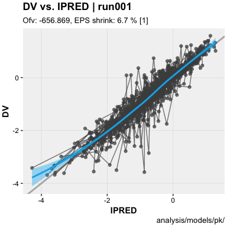

```r
# DV vs. IPRED plot
dv_vs_ipred(xpdb)
```

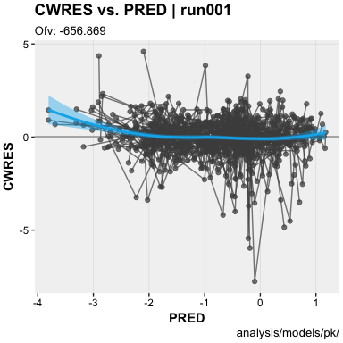

```r
# CWRES vs. PRED plot
cwres_vs_pred(xpdb)
```

### Exporting plots

The `xpose_save` function was designed to facilitated the export of plots from R to files. ggxpose will automatically save plots according to their run number and the plotting function using keywords preceded by a `@` you can learn more about these keywords using `help('template_titles')`. The file extension is guessed from the file name and must match one of .pdf, .jpeg, .png, .bmp or .tiff, if missing a pdf will be generated by default. Finally, if the `plot` argument is left empty `xpose_save` will automatically save the last plot that was generated by ggplot2.

```r
# Save the last plot
xpose_save()

# Change file name and extension
xpose_save(filename = '@run_@plotfun_[@ofv].jpeg')
```

### The pipes

`ggxpose` makes use of the pipe operator `%>%` from the package [dplyr](http://dplyr.tidyverse.org). Pipes can be used to generate clear workflow.

```r
xpose_data(runno = '001') %>%
  dv_vs_ipred() %>%
  xpose_save()
```